# Course_Project

BSantos

5/11/2020

# 1. Summary

Using devices such as Jawbone Up, Nike FuelBand, and Fitbit it is now possible to collect a large amount of data about personal activity relatively inexpensively. These type of devices are part of the quantified self movement – a group of enthusiasts who take measurements about themselves regularly to improve their health, to find patterns in their behavior, or because they are tech geeks. One thing that people regularly do is quantify how much of a particular activity they do, but they rarely quantify how well they do it. In this project, the goal is to predict the manner in which they did the exercise.

# 2. Load data and r packages

Load all necessary librariesin order to do this project. We will also set a seed to garantee reproducability of random results.

```r
    # Load r packages
    library(caret); library(gbm); library(randomForest);
    library(rpart); library(plyr); library(rattle); set.seed(666)
```

We will assume the files are already downloaded and saved in working directory.

```r
    # Save datasets from csv files, assuming the files are already stored in working directory
    train_data <- read.csv("pml-training.csv",header = TRUE)
    dim_traindata <- dim(train_data)
    test_data <- read.csv("pml-testing.csv", header = TRUE)
    dim_testdata <- dim(test_data)
```

The training data set, *train_data* has *19622* observations and *160* columns (variables), while test data set has the same number of columns but only *20* observations.

# 3. Clean data

After inspecting *train_data* we see that many variables have NA values, and the first seven columns include data regarding the subject. These type of informations will be removed in the following section.

```r
    # Train data cleaning
    train_data <- train_data[, colSums(is.na(train_data)) == 0]
    train_data <- train_data[,-c(1:7)]
```

```r
    # Test data cleaning
    test_data <- test_data[, colSums(is.na(test_data)) == 0]
    test_data <- test_data[,-c(1:7)]
```

To further clean train data set, we will remove variables with near zero variables.

```r
    # remove variables with near zero variance from training set
    nzvar <- nearZeroVar(train_data)
    train_data <- train_data[, -nzvar]
```

We will now prepare the data for prediction by splitting the training data into 75% as train data and 25% as test data.

```r
    # Create training & test dataset
    inTrain <- createDataPartition(train_data$classe, p = 0.75, list = FALSE)
    train_set <- train_data[inTrain,]
    test_set <- train_data[-inTrain,]
    dim(train_set)
```

```
## [1] 14718    53
```

```r
    dim(test_set)
```

```
## [1] 4904   53
```

After cleaning data, both training and test data set is now down to 53 variables.

# 4. Training Models

In this project will we conside three different training models:  
1. Random Forest  
2. Decision Tree  
3. Gradient boosting method

We will use the function trainControl with cross-validation, cv, criteria and number of folds equal to control computational nuances of the train function. This way, we wish to limit the effects of overfiting.

```r
    rfControl <- trainControl(method = "cv", number = 5, verboseIter=FALSE)
    # Random Forest training model
    mod_rf <- train(classe ~., data = train_set, method = "rf",trControl = rfControl)
```

```r
    # Decision Tree trainig model
    dtControl <- trainControl(method="cv", number=5)
    mod_dt <- train(classe ~., data = train_set, method = "rpart",trControl = dtControl)
```

```r
    # Gradient boosting method
    gbmControl <- trainControl(method="cv", number=5)
    mod_gbm <- train(classe ~., data = train_set, method = "gbm",trControl = gbmControl, verbose = FALSE)
```

# 5. Prediction

We now validade the models obtained in the previous section, using function predict, and afterwards, we check how well they perform by checking the accuracy value for each of them.

```r
    pred_rf <- predict(mod_rf, newdata = test_set)
    pred_gbm <- predict(mod_gbm, newdata = test_set)
    pred_dt <- predict(mod_dt, newdata = test_set)
```

Accuracy of random forest prediction method:

```r
    # Random forest accuracy
    cm_rf <- confusionMatrix(pred_rf, test_set$classe)
    cm_rf$overall[1]
```

```
##  Accuracy
## 0.9944943
```

Accuracy of decision tree prediction method:

```r
    # Decision Tree accuracy
    cm_dt <- confusionMatrix(pred_dt,test_set$classe)
    cm_dt$overall[1]
```

```
## Accuracy
## 0.490416
```

Accuracy of gradient boosting prediction method:

```r
    # Gradient boosting accuracy
    cm_gbm <- confusionMatrix(pred_gbm,test_set$classe)
    cm_gbm$overall[1]
```

```
##  Accuracy
## 0.9651305
```

# 6. Conclusions

Random forest model gives higher accuracy of 99.4% so we would apply this to predict the values of classe for the test data set.

```r
finalTest <- predict(mod_rf,newdata = test_data)
finalTest
```

```
##  [1] B A B A A E D B A A B C B A E E A B B B
## Levels: A B C D E
```

# Appendix

### Random Forest Method

```r
# display of random forest method
  print(cm_rf)
```

```
## Confusion Matrix and Statistics
##
##           Reference
## Prediction    A    B    C    D    E
##          A 1394    5    0    0    0
##          B    1  943    6    0    0
##          C    0    1  848   10    0
##          D    0    0    1  792    1
##          E    0    0    0    2  900
##
## Overall Statistics
##
##                Accuracy : 0.9945
##                  95% CI : (0.992, 0.9964)
##     No Information Rate : 0.2845
##     P-Value [Acc > NIR] : < 2.2e-16
##
##                   Kappa : 0.993
##  Mcnemar's Test P-Value : NA
##
## Statistics by Class:
##
##                      Class: A Class: B Class: C Class: D Class: E
## Sensitivity            0.9993   0.9937   0.9918   0.9851   0.9989
## Specificity            0.9986   0.9982   0.9973   0.9995   0.9995
## Pos Pred Value         0.9964   0.9926   0.9872   0.9975   0.9978
## Neg Pred Value         0.9997   0.9985   0.9983   0.9971   0.9998
## Prevalence             0.2845   0.1935   0.1743   0.1639   0.1837
## Detection Rate         0.2843   0.1923   0.1729   0.1615   0.1835
## Detection Prevalence   0.2853   0.1937   0.1752   0.1619   0.1839
## Balanced Accuracy      0.9989   0.9960   0.9945   0.9923   0.9992
```

### Decision Tress Method

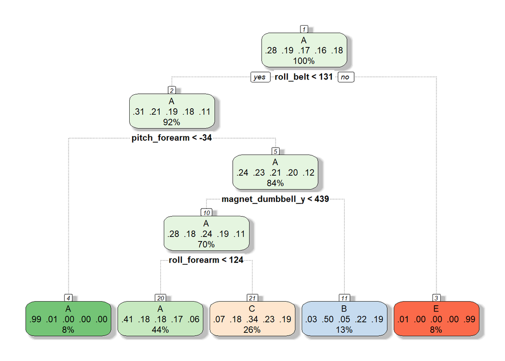

```r
    fancyRpartPlot(mod_dt$finalModel, sub = "")
```

Fig.1 - Classification Tree, 5 folds, using cross-validation technique.

```r
  # display of decision trees method
  print(cm_dt)
```

```
## Confusion Matrix and Statistics
##
##           Reference
## Prediction    A    B    C    D    E
##          A 1257  390  424  350  128
##          B   22  315   15  135  116
##          C  113  244  416  319  240
##          D    0    0    0    0    0
##          E    3    0    0    0  417
##
## Overall Statistics
##
##                Accuracy : 0.4904
##                  95% CI : (0.4763, 0.5045)
##     No Information Rate : 0.2845
##     P-Value [Acc > NIR] : < 2.2e-16
##
##                   Kappa : 0.3341
##  Mcnemar's Test P-Value : NA
##
## Statistics by Class:
##
##                      Class: A Class: B Class: C Class: D Class: E
## Sensitivity            0.9011  0.33193  0.48655   0.0000  0.46282
## Specificity            0.6318  0.92718  0.77377   1.0000  0.99925
## Pos Pred Value         0.4931  0.52239  0.31231      NaN  0.99286
## Neg Pred Value         0.9414  0.85259  0.87710   0.8361  0.89206
## Prevalence             0.2845  0.19352  0.17435   0.1639  0.18373
## Detection Rate         0.2563  0.06423  0.08483   0.0000  0.08503
## Detection Prevalence   0.5198  0.12296  0.27162   0.0000  0.08564
## Balanced Accuracy      0.7664  0.62955  0.63016   0.5000  0.73103
```

### Gradient Boosting Method

```r
  # display of decision trees method
  print(cm_gbm)
```

```
## Confusion Matrix and Statistics
##
##           Reference
## Prediction    A    B    C    D    E
##          A 1376   27    0    0    1
##          B   11  900   33    1    7
##          C    3   21  809   25    8
##          D    5    1   12  771    8
##          E    0    0    1    7  877
##
## Overall Statistics
##
##                Accuracy : 0.9651
##                  95% CI : (0.9596, 0.9701)
##     No Information Rate : 0.2845
##     P-Value [Acc > NIR] : < 2.2e-16
##
##                   Kappa : 0.9559
##  Mcnemar's Test P-Value : 0.0001033
##
## Statistics by Class:
##
##                      Class: A Class: B Class: C Class: D Class: E
## Sensitivity            0.9864   0.9484   0.9462   0.9590   0.9734
## Specificity            0.9920   0.9869   0.9859   0.9937   0.9980
## Pos Pred Value         0.9801   0.9454   0.9342   0.9674   0.9910
## Neg Pred Value         0.9946   0.9876   0.9886   0.9920   0.9940
## Prevalence             0.2845   0.1935   0.1743   0.1639   0.1837
## Detection Rate         0.2806   0.1835   0.1650   0.1572   0.1788
## Detection Prevalence   0.2863   0.1941   0.1766   0.1625   0.1805
## Balanced Accuracy      0.9892   0.9676   0.9661   0.9763   0.9857
```